# Modelagem Preditiva Avançada

## Regressão Logística

[output not shown]

Passo 1)

Primeiramente vamos importar os seguinter pacotes:

caret: Biblioteca para funcionalidade de ML

mlbench: Biblioteca para Validação de Modelos

ggplot2: Biblioteca para visualização de dados

pROC: Curva ROC

ROCR: Curva ROC

### Importando Bibliotecas e Dados

```r
options(warn=-1)
library(caret)
library(datasets)
library(mlbench)
library(ggplot2)

library(pROC)
library(ROCR)
```

Passo 2)

Agora vamos carregar o dataset, com cabeçalho (header=TRUE) e o separador de colunas sendo ','.

### Análise de Dados

```r
df <- read.csv(file="/home/barsotti/Desktop/SAT.csv", header=TRUE, sep=",")
```

Passo 3)

Agora vamos fazer uma rápida análise dos dados buscando identificar algumas relações visualmente e também verificar a qualidade dos dados.

```r
head(df)
```

| ADMIT | GRE | GPA | RANK |
| --- | --- | --- | --- |
| No | 380 | 3.61 | 3 |
| Yes | 660 | 3.67 | 3 |
| Yes | 800 | 4.00 | 1 |
| Yes | 640 | 3.19 | 4 |
| No | 520 | 2.93 | 4 |
| Yes | 760 | 3.00 | 2 |

```r
summary(df)
```

```
 ADMIT          GRE             GPA             RANK
 No :273   Min.   :220.0   Min.   :2.260   Min.   :1.000
 Yes:127   1st Qu.:520.0   1st Qu.:3.130   1st Qu.:2.000
           Median :580.0   Median :3.395   Median :2.000
           Mean   :587.7   Mean   :3.390   Mean   :2.485
           3rd Qu.:660.0   3rd Qu.:3.670   3rd Qu.:3.000
           Max.   :800.0   Max.   :4.000   Max.   :4.000
```

Passo 4)

Agora vamos particionar o dataset em treino/teste. Para isso definimos "p=0.7", isto é 70% da base será escolhida aleatóriamente para treino e 30% para teste do modelo.

Observe também que o "set.seed(x)" garante que ao replicarmos essa partição em outro computador por exemplo, os mesmos dados irão respectivamente prar treino e teste

```r
set.seed(280)
trainIndex <- createDataPartition(df$ADMIT, p = .7, list = FALSE)

df$ADMIT <- as.factor(df$ADMIT)
```

```r
dfTrain <- df[ trainIndex,]
dfTest  <- df[-trainIndex,]
```

Passo 5)

```r
set.seed(130)
options(warn=-1)
cv <- trainControl(method = "repeatedcv", number = 10, savePredictions = TRUE,
                  summaryFunction=twoClassSummary, classProbs = TRUE)


model <- train(ADMIT~., data = dfTrain, method = "glm",
                   metric="ROC",trControl = cv, control = list(maxit = 50))
```

Passo 6)

Chamando o modelo obtemos informações como:

Número de amostras no treino

Número de features preditoras

Sensitividade e Specificidade do Modelo

```r
model
```

```
Generalized Linear Model

281 samples
  3 predictor
  2 classes: 'No', 'Yes'

No pre-processing
Resampling: Cross-Validated (10 fold, repeated 1 times)
Summary of sample sizes: 253, 253, 252, 253, 253, 252, ...
Resampling results:

  ROC       Sens       Spec
  0.645307  0.9326316  0.1236111
```

Passo 7)

$z = \alpha_1(X_1) + \alpha_2(X_2) + \alpha_3(X_3) ....$

$z = \alpha_1(RANK) + \alpha_2(GPA) +\alpha_3(GRE) ....$

$Pr(Approved=Yes) = \frac{1}{1+e^{-z}}$

```r
dfPred <- predict(model, newdata=dfTest)
```

Passo 8)

Adicionando matriz de confusão para validação do modelo logístico.

### Matriz de Confusão

```r
confusionMatrix(data=dfPred, dfTest$ADMIT)
```

```
Confusion Matrix and Statistics

          Reference
Prediction No Yes
       No  78  27
       Yes  3  11

               Accuracy : 0.7479
                 95% CI : (0.6601, 0.823)
    No Information Rate : 0.6807
    P-Value [Acc > NIR] : 0.06799

                  Kappa : 0.3033
 Mcnemar's Test P-Value : 2.679e-05

            Sensitivity : 0.9630
            Specificity : 0.2895
         Pos Pred Value : 0.7429
         Neg Pred Value : 0.7857
             Prevalence : 0.6807
         Detection Rate : 0.6555
   Detection Prevalence : 0.8824
      Balanced Accuracy : 0.6262

       'Positive' Class : No
```

Passo 9)

Agora podemos fazer o score do modelo na base de teste e obter as probabilidades de cada classe de acordo com o modelo

```r
dfProbs <- predict(model, newdata=dfTest, type="prob")
head(dfProbs)
```

|  | No | Yes |
| --- | --- | --- |
| 3 | 0.3350590 | 0.6649410 |
| 5 | 0.8750881 | 0.1249119 |
| 7 | 0.6269985 | 0.3730015 |
| 11 | 0.6521917 | 0.3478083 |
| 13 | 0.3523828 | 0.6476172 |
| 21 | 0.7977129 | 0.2022871 |

Passo 10)

Agora usando a biblioteca pROC vamos fazer um plot da curva ROC

0.756172839506173

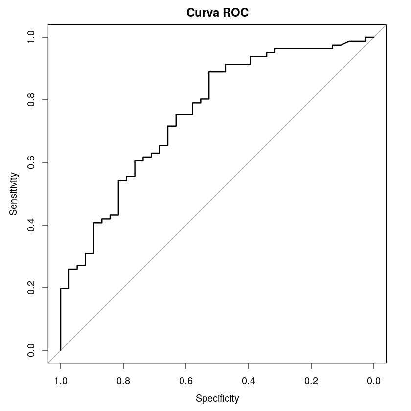

```r
gbm.ROC <- roc(predictor=dfProbs$Yes,
               response=dfTest$ADMIT,
               levels=rev(levels(dfTest$ADMIT)))

gbm.ROC$auc
plot(gbm.ROC,main="Curva ROC")
```

Passo 11)

```
ROC curve variable importance

     Importance
RANK     0.6151
GPA      0.6043
GRE      0.5896
```

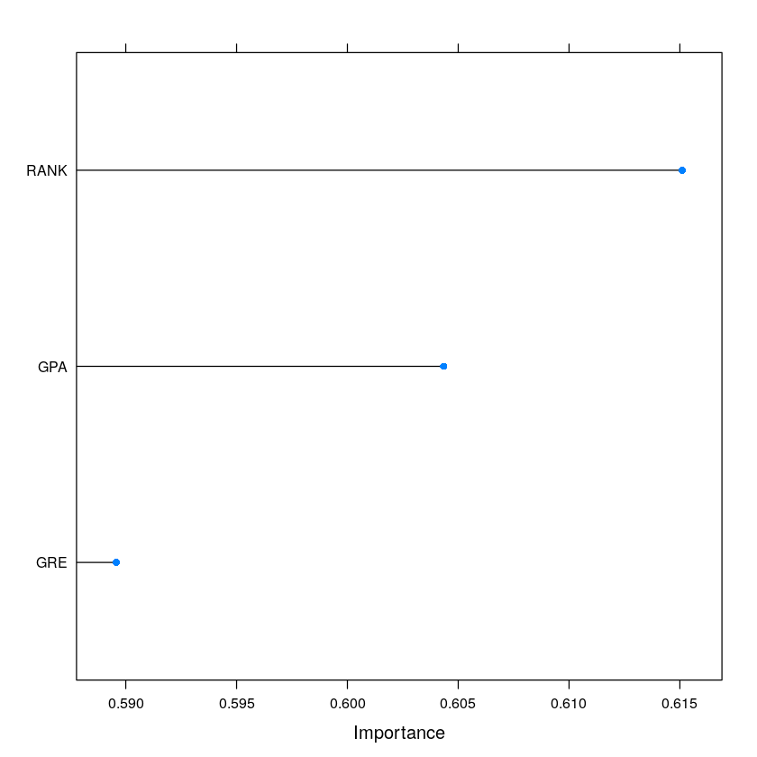

```r
imp <- varImp(model, useModel=FALSE, scale=FALSE)
imp
plot(imp)
```